[figure not shown]

## Assessment 4

### Analysis of mao {gap.datasets}

> **Course Name**: Introduction to Programming and Data Visualization

> **Course Instructor**: Prof. Dr. Florian Artinger

> **Student Name**: Eyüp Orhan Tükenmez

> **Student Id**: 2102561

| mao | R Documentation | A study of Parkinson’s disease and MAO gene |
| --- | --- | --- |

Description: The markers are both with actual allele sizes and allele numbers. The dataset is distributed with the GENECOUNTING version 2.0 illustrating gene counting method involving chromosome X. A total of 183 patients and 157 controls (150 males, 190 females) were available, together with five markers in MAOA (monoamine oxidase A) region with alleles 12, 9, 6, 5, 3, and the first three markers were genotyped in all individuals while the fourth and fifth were genotyped for 294 and 304 individuals.

Source: Dr Helen Latsoudis of Institute of Psychiatry, KCL

References: Zhao JH (2004). 2LD, GENECOUNTING and HAP: computer programs for linkage disequilibrium analysis. Bioinformatics 20:1325-1326.

### Description of the MAO dataset and variables

Parkinson’s disease (PD) is the second most common, age-related neurodegenerative disorder, affecting about 3% of the population by the age of 65 and up to 5% of the people over 85 years (Dexter, D. T. Et al., 2013).

The MAO dataset contains observations over a study of Parkinson’s disease and MAO (monoamine oxidase A) gene using a gene counting method involving chromosome X. Five markers in the MAOA region with alleles 12, 9, 6, 5, 3 are observed in the study.

Description of the variables

| Column | Type | Description |
| --- | --- | --- |
| id | character | Patient ID. |
| type | numeric | Type of patient. 1=Patients (183), 0=Control group (157). |
| gender | numeric | Patient gender information 0=male (150) , 1=female (190). |
| age | numeric | Patients age (years). |
| aao | numeric | Patients age at disease onset (years). |
| aad | numeric | Patients age at deep brain stimulation (DBS) operation (years). |
| updrs | numeric | Unified Parkinson Disease Rating Scale (UPDRS). |
| maoai2 | character | Monoamine Oxidase A (MAO-A) gene, imidazoline I2 receptor. |
| ai2code | character | MAO-A I2 code. |
| maobi2 | character | MAO-A BI2 receptor. |
| bi2code | character | MAO-A BI2 code. |
| gtbex3 | character | Gene (Protein Coding), Brain Expressed X-Linked 3 (BEX3). |
| bex3code | character | BEX3 code. |
| maoavntr | character | Variable number of tandem repeats (VNTR), repeated DNA sequences in a genome. |
| vntrcode | character | VNTR sequence code. |
| vntrcod2 | character | VNTR sequence code 2. |
| maoa31 | character | B-cell receptor-associated protein 31 (Bap31), negatively regulates the expression of MAO-A via R1. |
| mao31cod | character | MAO-A Bap31 code. |
| mao31co2 | character | MAO-A Bap31 code 2. |

**NOTICE!**

Variable descriptions table above mainly consists of definitions available at the Genecards.org. Author of this report has no medical science knowledge. Therefore please refer to the sources listed in the references section for accurate scientific information on **monoamine oxidase** and human genes.

```r
# install.packages("gap")
library(gap.datasets)
library(tidyverse)
theme_set(theme_bw() + theme(legend.position = "top"))
library(dplyr)
```

### Summary statistics on variation of the variables in MAO dataset

```r
data <- mao
# Clean up empty strings
remove_empty <- function(observed) {
  result <- replace(observed, str_trim(observed) == "", NA)
  result
}
data <- data %>% mutate_all(~ remove_empty(.))

# Label the columns type and gender
data$type <- factor(data$type, levels = c("0", "1"),
                  labels = c("Control", "Patient"))
data$gender <- factor(data$gender, levels = c("0", "1"),
                  labels = c("Male", "Female"))

data %>%
  group_by(type, gender) %>%
  summarize(count =  n(),
            min_age = min(age, na.rm = TRUE),
            max_age = max(age, na.rm = TRUE),
            mean_age = mean(age, na.rm = TRUE),
            stdev_age = sd(age, na.rm = TRUE))
```

| type | gender | count | min_age | max_age | mean_age | stdev_age |
| --- | --- | --- | --- | --- | --- | --- |
| Control | Male | 69 | 26 | 84 | 64.44444 | 11.041336 |
| Control | Female | 88 | 44 | 84 | 65.02778 | 10.527477 |
| Patient | Male | 81 | 76 | 91 | 81.52632 | 3.725274 |
| Patient | Female | 102 | 75 | 91 | 81.40476 | 4.638437 |

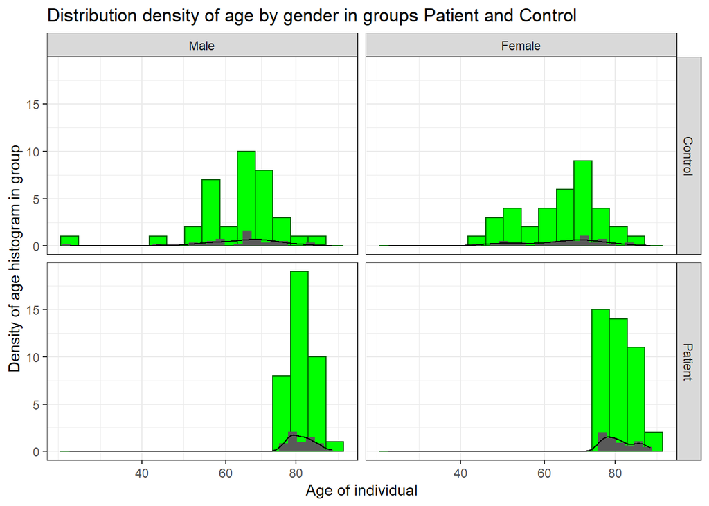

```r
# Note that data is ignored when age information is unknown.
data %>%
  ggplot(aes(x=age)) +
  geom_histogram(colour = "darkgreen", fill = "green", binwidth = 0.3) +
  geom_histogram(aes(y = ..density..)) +
  geom_density(alpha = 0.1) +
  scale_x_sqrt() +
  facet_grid(type~gender) +
  ggtitle('Distribution density of age by gender in groups Patient and Control') +
  labs(x = "Age of individual") +
  labs(y = "Density of age histogram in group")
```

**NOTICE!**

Control group consists significantly younger individuals compared to patients and it has outliers. Control skewed left while patients group skewed right unimodal age distributions. Male patient group has an age distribution which is much close to the normal distribution model than the others.

Following table lists the genotyped gene markers of all individuals in patient and control group by gender.

Gene markers

|  | **Gene** | **Male Patients** | **Female Patients** | **Male Control** | **Female Control** | **Total** |
| --- | --- | --- | --- | --- | --- | --- |
|  | maoai2 | 81 | 102 | 69 | 88 | 340 |
|  | maobi2 | 81 | 102 | 69 | 88 | 340 |
|  | gtbex3 | 81 | 102 | 69 | 88 | 340 |
|  | maoavntr | 71 | 96 | 52 | 75 | 294 |
|  | maoa31 | 77 | 100 | 52 | 75 | 304 |

```r
# Top three most genotyped markers in both groups. Ties inclusive. NA values inclusive.
data %>% count(type,maoai2,maobi2,gtbex3,maoavntr,maoa31, sort = TRUE) %>%
  slice_max(n, n = 3, with_ties = TRUE)
```

| type | maoai2 | maobi2 | gtbex3 | maoavntr | maoa31 | n |
| --- | --- | --- | --- | --- | --- | --- |
| Control | 112 | 179 | 243 | 319 | 334 | 4 |
| Control | 110 | 177 | 255 | 349 | 338 | 3 |
| Control | 110/112 | 181/181 | 255/255 | 349/349 | 338/338 | 3 |
| Control | 112 | 175 | 255 | NA | NA | 3 |
| Patient | 112 | 177 | 255 | 349 | 338 | 3 |
| Patient | 112 | 181 | 255 | 349 | 338 | 3 |
| Patient | 124 | 179 | 255 | 319 | 308 | 3 |

```r
# List of individuals with most appearing combination of markers (maoai2:112, maobi2:179, gtbex3:243, maoavntr:319, maoa31:334).
data %>%
  filter(maoai2 == '112', maobi2 == '179', gtbex3 == '243', maoavntr == '319', maoa31 == '334')  %>%
  select(type,gender,age,maoai2,maobi2,gtbex3,maoavntr,maoa31)
```

|  | type | gender | age | maoai2 | maobi2 | gtbex3 | maoavntr | maoa31 |
| --- | --- | --- | --- | --- | --- | --- | --- | --- |
| 82 | Control | Male | 65 | 112 | 179 | 243 | 319 | 334 |
| 143 | Control | Male | 75 | 112 | 179 | 243 | 319 | 334 |
| 144 | Control | Male | 58 | 112 | 179 | 243 | 319 | 334 |
| 145 | Control | Male | NA | 112 | 179 | 243 | 319 | 334 |
| 230 | Patient | Male | NA | 112 | 179 | 243 | 319 | 334 |

**NOTICE!**

In control group, individuals with the markers in combination of *maoai2:112, maobi2:179, gtbex3:243, maoavntr:319, maoa31:334* appears four times which is the *highest frequency* in this dataframe. And there is **only one male patient** with the same markers.

### Gene marker: maoai2

```r
# maoai2
m1 <- data %>%
  group_by(type, gender, maoai2) %>%
  summarise(count = n()) %>%
  mutate(gene = "maoai2")
m1 <- select(m1, -maoai2)
m1 <- m1 %>%
  group_by(type, gender, gene) %>%
  summarise(n=list(sum(count)))

m1 %>%
  ggplot(aes(type, n, fill = gender)) +
  geom_bar(stat = "identity") +
  labs(x = "Group of individual") +
  labs(y = "Count of individual")
```

[output not shown]

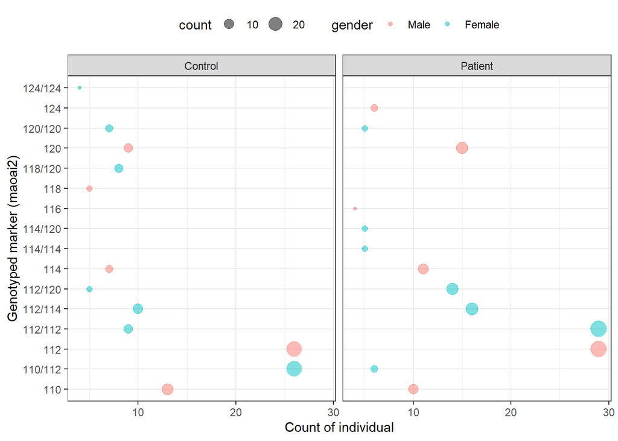

```r
data %>%
  group_by(maoai2,type, gender) %>%
  summarise(count = n()) %>%
  filter(count > 3) %>%
  arrange(desc(count)) %>%
  ggplot(aes(count, maoai2, color=gender, size = count)) +
  geom_point(alpha=0.5) +
  facet_wrap(~type) +
  labs(x = "Count of individual") +
  labs(y = "Genotyped marker (maoai2)")
```

### Three most genotyped maoai2 gene markers in both P/C groups by gender.

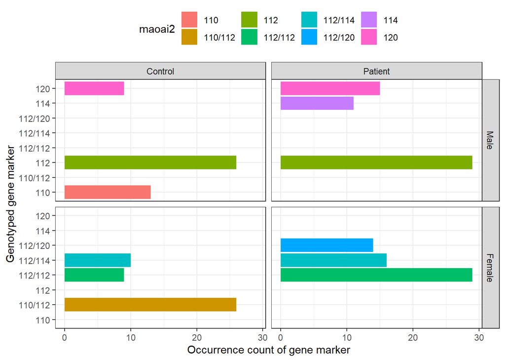

```r
# Most genotyped three maoai2 markers grouped by gender and ties inclusive. Omit null values.
data %>%
  group_by(across(all_of(c('type','gender','maoai2')))) %>%
  filter(all(!is.na(maoai2))) %>%
  summarise(n = n()) %>%
  slice_max(n, n = 3, with_ties = TRUE) %>%
  mutate(gene = 'maoai2', value = maoai2) %>%
  ggplot(aes(n, maoai2, fill = maoai2)) +
  geom_bar(stat = "identity") +
  facet_grid(gender~type) +
  labs(y = "Genotyped gene marker") +
  labs(x = "Occurrence count of gene marker")
```

**NOTICE!**

Observations of females have double value sets because female humans have a pair of X **(XX)** chromosomes while human male chromosomes have only one X **(XY)**.

**NOTICE!**

The maoai2 markers in **female control group** genotyped with **110/112** appears fairly frequent (26 occurrences, 29.55% in female control, 13.68% in all females) while they appear relatively less in patient group (6 occurrences, 5.88% in female patient, 3.16% in all females. Not in above graph because of low frequency).

### Gene marker: maobi2

```r
# maobi2
m2 <- data %>%
  group_by(type, gender, maobi2) %>%
  summarise(count = n()) %>%
  mutate(gene = "maobi2")
m2 <- select(m2, -maobi2)
m2 <- m2 %>%
  group_by(type, gender, gene) %>%
  summarise(n=list(sum(count)))

m2 %>%
  ggplot(aes(type, n, fill = gender)) +
  geom_bar(stat = "identity") +
  labs(x = "Group of individual") +
  labs(y = "Count of individual")
```

[output not shown]

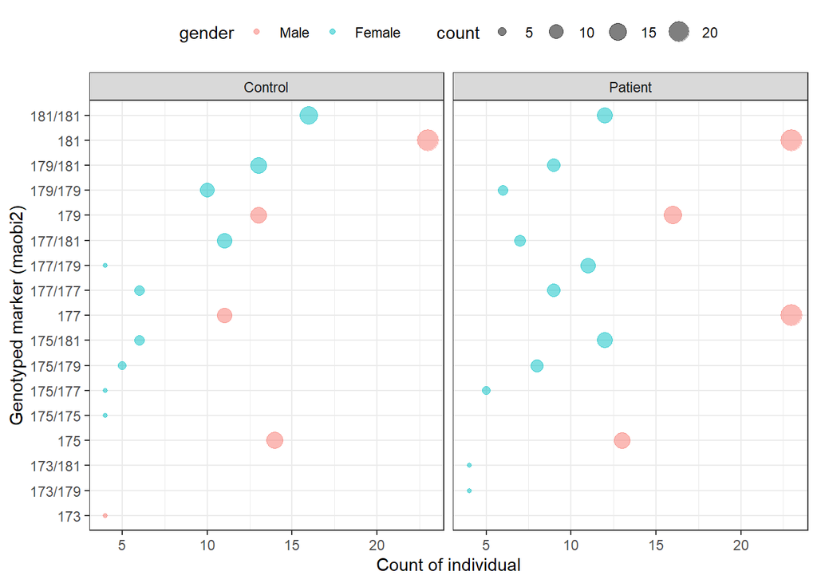

```r
data %>%
  group_by(maobi2,type, gender) %>%
  summarise(count = n()) %>%
  filter(count > 3) %>%
  arrange(desc(count)) %>%
  ggplot(aes(count, maobi2, color=gender, size = count)) +
  geom_point(alpha=0.5) +
  facet_wrap(~type) +
  labs(x = "Count of individual") +
  labs(y = "Genotyped marker (maobi2)")
```

### Three most genotyped maobi2 gene markers in both P/C groups by gender.

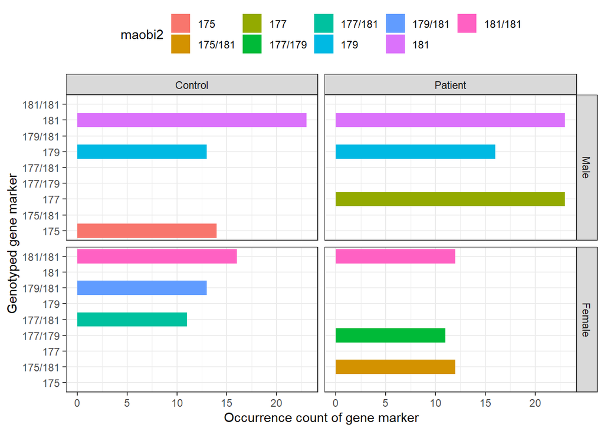

```r
# Most genotyped three maobi2 markers grouped by gender and ties inclusive. Omit null values.
data %>%
  group_by(across(all_of(c('type','gender','maobi2')))) %>%
  filter(all(!is.na(maobi2))) %>%
  summarise(n = n()) %>%
  slice_max(n, n = 3, with_ties = TRUE) %>%
  mutate(gene = 'maobi2', value = maobi2) %>%
  ggplot(aes(n, maobi2, fill = maobi2)) +
  geom_bar(stat = "identity") +
  facet_grid(gender~type) +
  labs(y = "Genotyped gene marker") +
  labs(x = "Occurrence count of gene marker")
```

**NOTICE!**

The maobi2 markers in **male patient group** genotyped with **177** appears fairly frequent (23 occurrences, 28.40% in male patient, 15.33% in all males) while they appear relatively less in control group (11 occurrences, 15.94% in male control, 7.33% in all males. Not in above graph because of low frequency).

### Gene marker: gtbex3

```r
# gtbex3
m3 <- data %>%
  group_by(type, gender, gtbex3) %>%
  summarise(count = n()) %>%
  mutate(gene = "gtbex3")
m3 <- select(m3, -gtbex3)
m3 <- m3 %>%
  group_by(type, gender, gene) %>%
  summarise(n=list(sum(count)))

m3 %>%
  ggplot(aes(type, n, fill = gender)) +
  geom_bar(stat = "identity") +
  labs(x = "Group of individual") +
  labs(y = "Count of individual")
```

[output not shown]

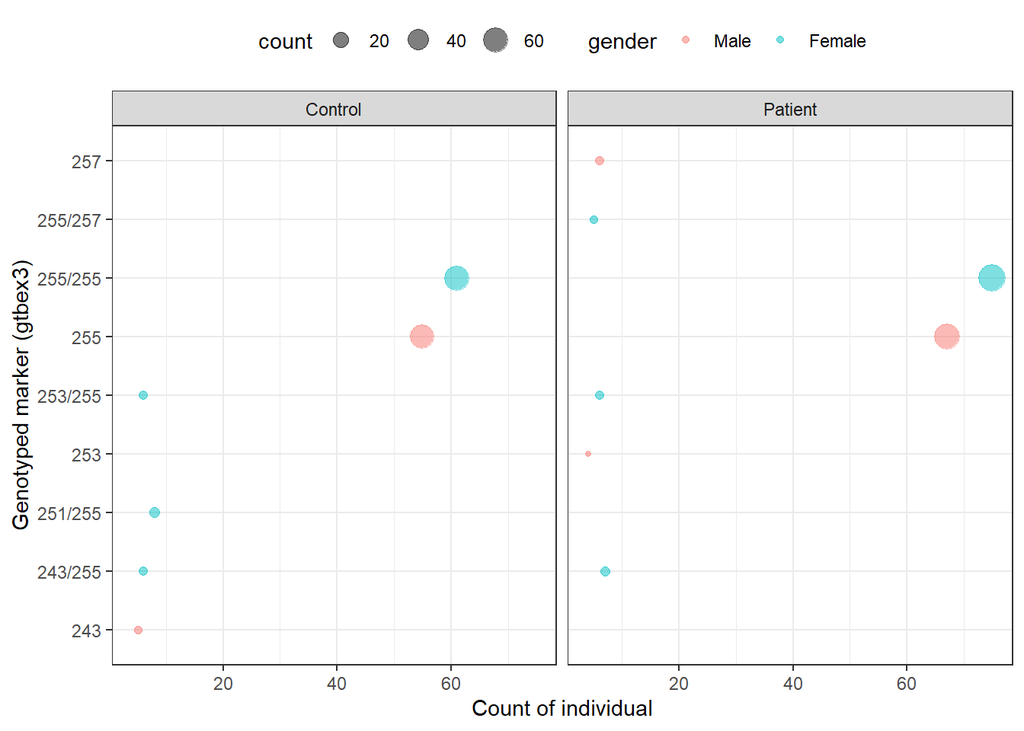

```r
data %>%
  group_by(gtbex3,type, gender) %>%
  summarise(count = n()) %>%
  filter(count > 3) %>%
  arrange(desc(count)) %>%
  ggplot(aes(count, gtbex3, color=gender, size = count)) +
  geom_point(alpha=0.5) +
  facet_wrap(~type) +
  labs(x = "Count of individual") +
  labs(y = "Genotyped marker (gtbex3)")
```

### Three most genotyped gtbex3 gene markers in both P/C groups by gender.

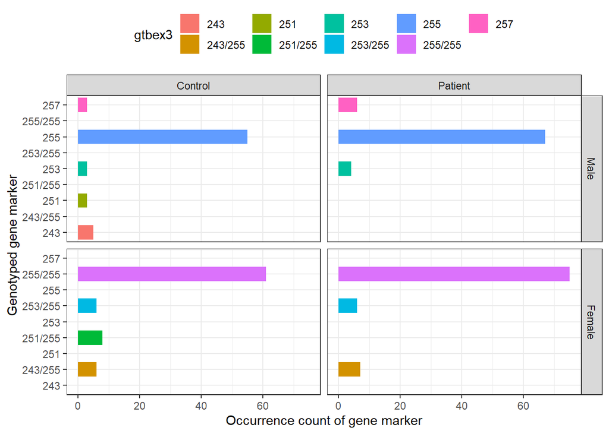

```r
# Most genotyped three gtbex3 markers grouped by gender and ties inclusive. Omit null values.
data %>%
  group_by(across(all_of(c('type','gender','gtbex3')))) %>%
  filter(all(!is.na(gtbex3))) %>%
  summarise(n = n()) %>%
  slice_max(n, n = 3, with_ties = TRUE) %>%
  mutate(gene = 'gtbex3', value = gtbex3) %>%
  ggplot(aes(n, gtbex3, fill = gtbex3)) +
  geom_bar(stat = "identity") +
  facet_grid(gender~type) +
  labs(y = "Genotyped gene marker") +
  labs(x = "Occurrence count of gene marker")
```

**NOTICE!**

The gtbex3 markers in **female control group** genotyped with **251/255** appears frequent (8 occurrences, 9.09% in female control, 4.21% in all females) while they appear relatively less in patient group (2 occurrences, 1.96% in female patient, 1.05% in all females. Not in above graph because of low frequency).

### Gene marker: maoavntr

```r
# maoavntr
m4 <- data %>%
  group_by(type, gender, maoavntr) %>%
  summarise(count = n()) %>%
  mutate(gene = "maoavntr")
m4 <- select(m4, -maoavntr)
m4 <- m4 %>%
  group_by(type, gender, gene) %>%
  summarise(n=list(sum(count)))

m4 %>%
  ggplot(aes(type, n, fill = gender)) +
  geom_bar(stat = "identity") +
  labs(x = "Group of individual") +
  labs(y = "Count of individual")
```

[output not shown]

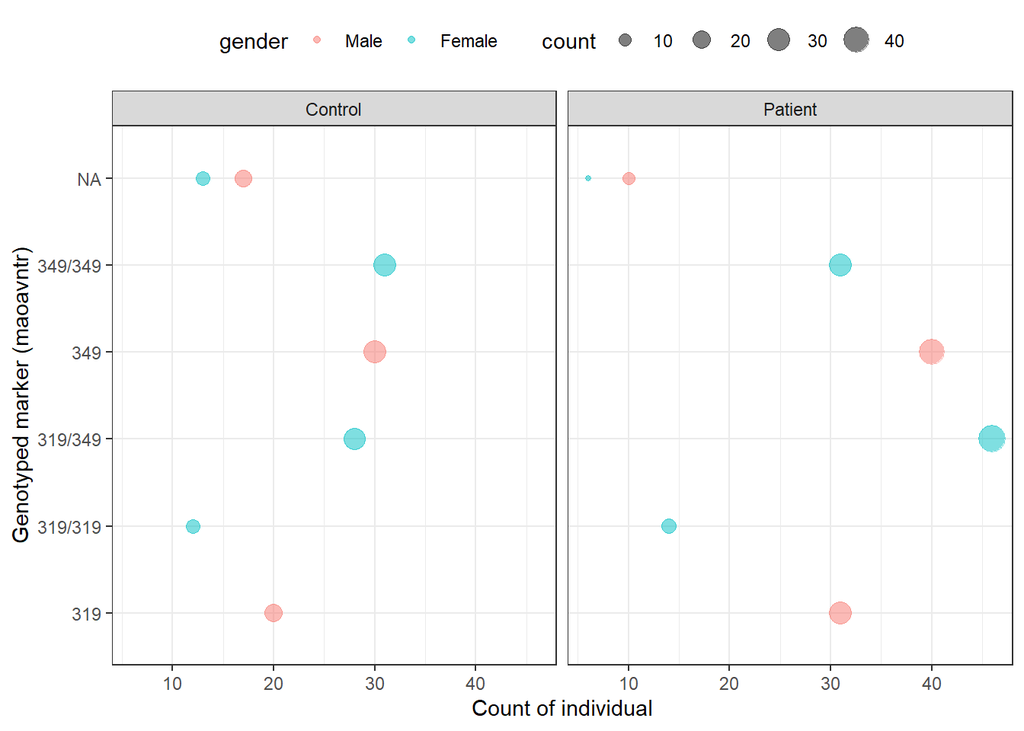

```r
data %>%
  group_by(maoavntr,type, gender) %>%
  summarise(count = n()) %>%
  filter(count > 3) %>%
  arrange(desc(count)) %>%
  ggplot(aes(count, maoavntr, color=gender, size = count)) +
  geom_point(alpha=0.5) +
  facet_wrap(~type) +
  labs(x = "Count of individual") +
  labs(y = "Genotyped marker (maoavntr)")
```

### Three most genotyped maoavntr gene markers in both P/C groups by gender.

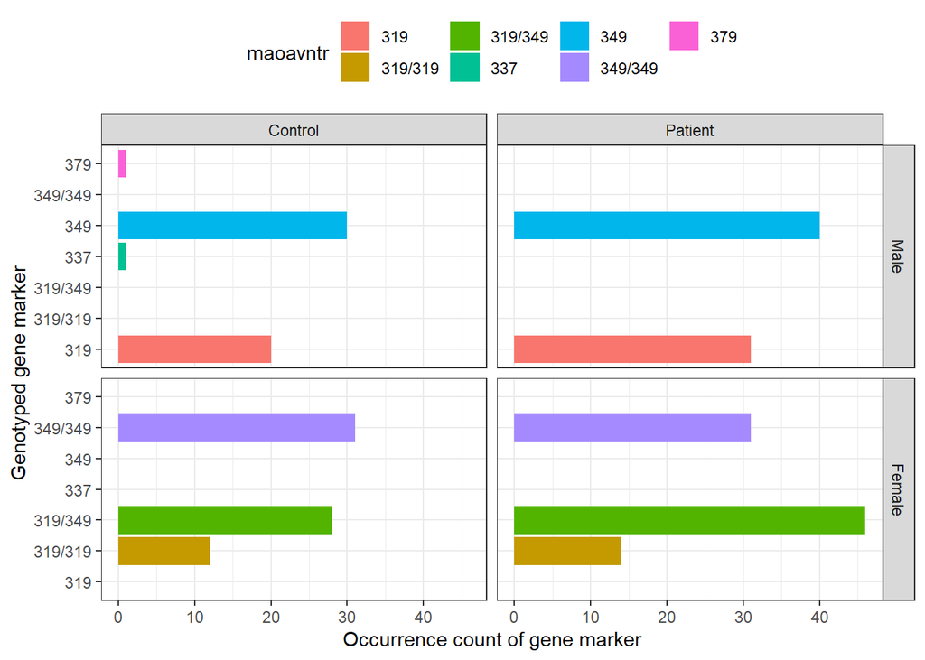

```r
# Most genotyped three maoavntr markers grouped by gender and ties inclusive. Omit null values.
data %>%
  group_by(across(all_of(c('type','gender','maoavntr')))) %>%
  filter(all(!is.na(maoavntr))) %>%
  summarise(n = n()) %>%
  slice_max(n, n = 3, with_ties = TRUE) %>%
  mutate(gene = 'maoavntr', value = maoavntr) %>%
  ggplot(aes(n, maoavntr, fill = maoavntr)) +
  geom_bar(stat = "identity") +
  facet_grid(gender~type) +
  labs(y = "Genotyped gene marker") +
  labs(x = "Occurrence count of gene marker")
```

**NOTICE!**

The maoavntr does not show significant differences between groups of individuals in comparison to other genes, **gtbex3 and maoavntr** have the most symmetric distributions.

### Gene marker: maoa31

```r
# maoa31
m5 <- data %>%
  group_by(type, gender, maoa31) %>%
  summarise(count = n()) %>%
  mutate(gene = "maoa31")
m5 <- select(m5, -maoa31)
m5 <- m5 %>%
  group_by(type, gender, gene) %>%
  summarise(n=list(sum(count)))

m5 %>%
  ggplot(aes(type, n, fill = gender)) +
  geom_bar(stat = "identity") +
  labs(x = "Group of individual") +
  labs(y = "Count of individual")
```

[output not shown]

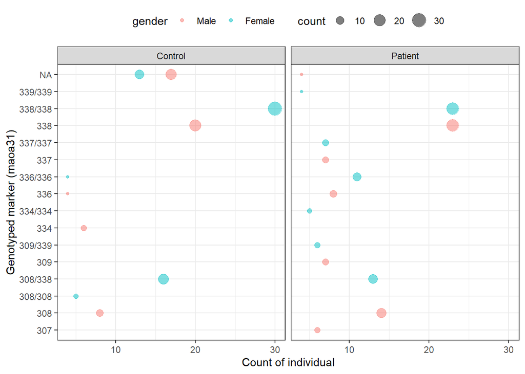

```r
data %>%
  group_by(maoa31,type, gender) %>%
  summarise(count = n()) %>%
  filter(count > 3) %>%
  arrange(desc(count)) %>%
  ggplot(aes(count, maoa31, color=gender, size = count)) +
  geom_point(alpha=0.5) +
  facet_wrap(~type) +
  labs(x = "Count of individual") +
  labs(y = "Genotyped marker (maoa31)")
```

### Three most genotyped maoa31 gene markers in both P/C groups by gender.

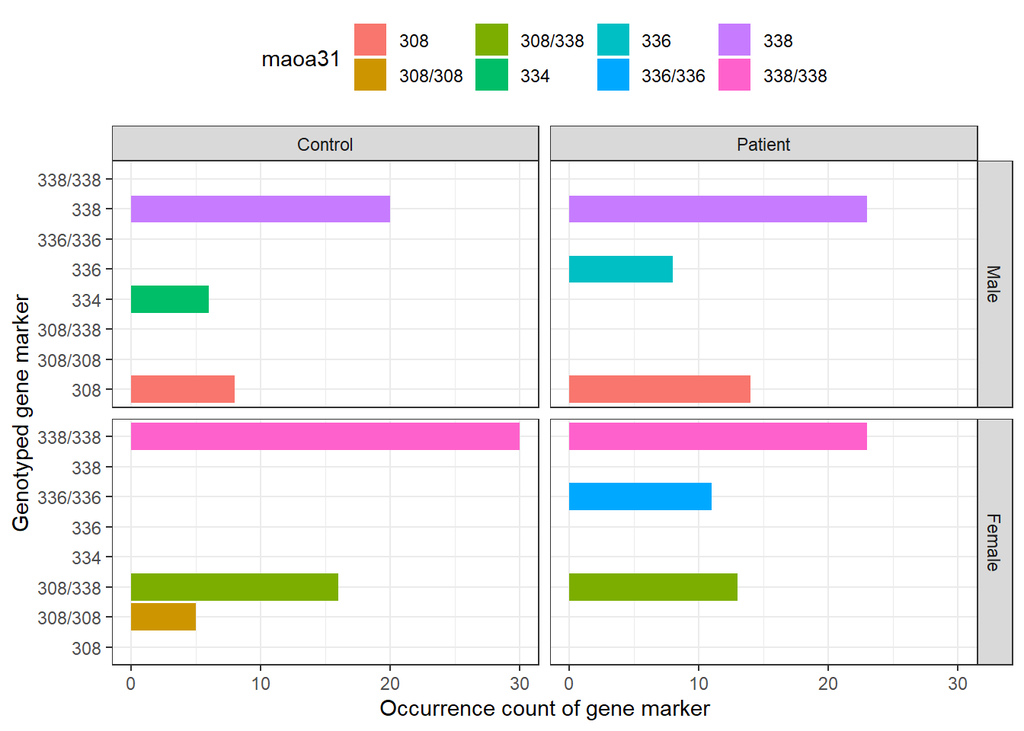

```r
# Most genotyped three maoa31 markers grouped by gender and ties inclusive. Omit null values.
data %>%
  group_by(across(all_of(c('type','gender','maoa31')))) %>%
  filter(all(!is.na(maoa31))) %>%
  summarise(n = n()) %>%
  slice_max(n, n = 3, with_ties = TRUE) %>%
  mutate(gene = 'maoa31', value = maoa31) %>%
  ggplot(aes(n, maoa31, fill = maoa31)) +
  geom_bar(stat = "identity") +
  facet_grid(gender~type) +
  labs(y = "Genotyped gene marker") +
  labs(x = "Occurrence count of gene marker")
```

**NOTICE!**

The maoa31 markers in **female patient group** genotyped with **336/336** appears frequent (11 occurrences, 10.78% in female patient, 5.79% in all females) while they appear relatively less in control group (4 occurrences, 4.55% in female control, 2.11% in all females. Not in above graph because of low frequency).

### Analysis of data and hypothesis testing.

- We will test the hypothesis question: ’**Does the maoa31 gene genotyped marker’s average occurrence frequency differ between groups?**’.
- Patient group: 81 male and 102 female individuals.
- Control group: 69 male and 88 female individuals.
- Test problem: H0 : µX = µY vs Ha : µX ̸= µY.
- Idea: Reject null hypothesis if ¯x − ¯y is large.

```r
# maoa31_freq
maoa31_freq <- data %>%
  group_by(across(all_of(c('type','gender','maoa31')))) %>%
  filter(!is.na(maoa31)) %>%
  summarise(n = n()) %>%
  mutate(freq = n/sum(n))

maoa31_freq
```

| type | gender | maoa31 | n | freq |
| --- | --- | --- | --- | --- |
| Control | Male | 307 | 1 | 0.01923077 |
| Control | Male | 308 | 8 | 0.15384615 |
| Control | Male | 309 | 2 | 0.03846154 |
| Control | Male | 310 | 2 | 0.03846154 |
| Control | Male | 313 | 1 | 0.01923077 |
| Control | Male | 314 | 1 | 0.01923077 |
| Control | Male | 318 | 1 | 0.01923077 |
| Control | Male | 332 | 2 | 0.03846154 |
| Control | Male | 333 | 1 | 0.01923077 |
| Control | Male | 334 | 6 | 0.11538462 |

[output cut: 61 more lines]

```r
# For Student's t-test, specify the option var.equal=TRUE:
ttest <- t.test(freq ~ type, data = maoa31_freq
              , var.equal = TRUE
              , conf.level = 0.95)
ttest
```

```
##
##  Two Sample t-test
##
## data:  freq by type
## t = 0.75165, df = 69, p-value = 0.4548
## alternative hypothesis: true difference in means between group Control and group Patient is not equal to 0
## 95 percent confidence interval:
##  -0.02401114  0.05304340
## sample estimates:
## mean in group Control mean in group Patient
##            0.06451613            0.05000000
```

- t is the t-test statistic value (t = 0.75165),
- df is the degrees of freedom (df= 69),
- p-value is the significance level of the t-test (p-value = 0.4548).
- conf.int is the confidence interval of the means difference at 95% (conf.int = [-0.02401114,0.05304340]);
- sample estimates is the mean value of the sample (mean = 0.06451613, 0.05000000).
- alpha = 0.05 < 0.4548 thus **we retain the null hypothesis**.

**NOTICE!**

### References

References

[output not shown]

image: Flaticon.com